# R Notebook

In this notebook, the baseline model for the data set called “data” will be documented.

First, the data will be arranged by date and then divided into a training data set (01.07.2013 until 31.07.2017) and a validation data set (01.08.2017 until 31.07.2018).

```r
# import libraries
library("readr")
library("dplyr")
# load csv-file with all data
data <- read_csv("../0_DataPreparation/data.csv")
# sort data by Datum
data_sorted <- data %>% arrange(Datum)
head(data_sorted)
```

| id | Datum | Warengruppe | Umsatz | KielerWoche | Bewoelkung | Temperatur | Windgeschwindigkeit | Wettercode | Schulferien | Feiertag | Wochenende | Season |
| --- | --- | --- | --- | --- | --- | --- | --- | --- | --- | --- | --- | --- |
| NA | 2012-01-01 | NA | NA | 0 | 8 | 9.8250 | 14 | 58 | 0 | NA | 1 | Winter |
| NA | 2012-01-02 | NA | NA | 0 | 7 | 7.4375 | 12 | NA | 0 | NA | 0 | Winter |
| NA | 2012-01-03 | NA | NA | 0 | 8 | 5.5375 | 18 | 63 | 0 | NA | 0 | Winter |
| NA | 2012-01-04 | NA | NA | 0 | 4 | 5.6875 | 19 | 80 | 0 | NA | 0 | Winter |
| NA | 2012-01-05 | NA | NA | 0 | 6 | 5.3000 | 23 | 80 | 0 | NA | 0 | Winter |
| NA | 2012-01-06 | NA | NA | 0 | 3 | 2.6250 | 10 | NA | 0 | NA | 0 | Winter |

```r
# delete unnecessary rows without Umsatz-data, which starts at 2013-07-01
data_sorted_filter <- data_sorted %>%
  filter(Datum >= as.Date('2013-07-01'))

# divide data into training and validation set
training_data <- data_sorted_filter %>% filter(Datum <= "2017-07-31")
validation_data <- data_sorted_filter %>% filter(Datum >= "2017-08-01" & Datum <= "2018-07-31")
test_data2 <- data_sorted_filter %>% filter(Datum >= "2018-08-01")

# check new data sets
head(training_data)
```

| id | Datum | Warengruppe | Umsatz | KielerWoche | Bewoelkung | Temperatur | Windgeschwindigkeit | Wettercode | Schulferien | Feiertag | Wochenende | Season |
| --- | --- | --- | --- | --- | --- | --- | --- | --- | --- | --- | --- | --- |
| 1307011 | 2013-07-01 | 1 | 148.82835 | 0 | 6 | 17.8375 | 15 | 20 | 1 | 0 | 0 | Summer |
| 1307012 | 2013-07-01 | 2 | 535.85628 | 0 | 6 | 17.8375 | 15 | 20 | 1 | 0 | 0 | Summer |
| 1307013 | 2013-07-01 | 3 | 201.19843 | 0 | 6 | 17.8375 | 15 | 20 | 1 | 0 | 0 | Summer |
| 1307014 | 2013-07-01 | 4 | 65.89017 | 0 | 6 | 17.8375 | 15 | 20 | 1 | 0 | 0 | Summer |
| 1307015 | 2013-07-01 | 5 | 317.47587 | 0 | 6 | 17.8375 | 15 | 20 | 1 | 0 | 0 | Summer |
| 1307021 | 2013-07-02 | 1 | 159.79376 | 0 | 3 | 17.3125 | 10 | NA | 1 | 0 | 0 | Summer |

```r
head(validation_data)
```

| id | Datum | Warengruppe | Umsatz | KielerWoche | Bewoelkung | Temperatur | Windgeschwindigkeit | Wettercode | Schulferien | Feiertag | Wochenende | Season |
| --- | --- | --- | --- | --- | --- | --- | --- | --- | --- | --- | --- | --- |
| 1708011 | 2017-08-01 | 1 | 166.13549 | 0 | 6 | 21.375 | 7 | 21 | 1 | 0 | 0 | Summer |
| 1708012 | 2017-08-01 | 2 | 557.47090 | 0 | 6 | 21.375 | 7 | 21 | 1 | 0 | 0 | Summer |
| 1708013 | 2017-08-01 | 3 | 294.87270 | 0 | 6 | 21.375 | 7 | 21 | 1 | 0 | 0 | Summer |
| 1708014 | 2017-08-01 | 4 | 88.20801 | 0 | 6 | 21.375 | 7 | 21 | 1 | 0 | 0 | Summer |
| 1708015 | 2017-08-01 | 5 | 325.86423 | 0 | 6 | 21.375 | 7 | 21 | 1 | 0 | 0 | Summer |
| 1708021 | 2017-08-02 | 1 | 155.02210 | 0 | 5 | 21.375 | 8 | 61 | 1 | 0 | 0 | Summer |

Before the linear regression, all variables will be looked at in case they need to be adjusted:

```r
# How to bin the temperature data?
# looking at the min, max and mean
summary(training_data$Temperatur)  # data ranges from -8.475 to 31.438 degrees
```

```
   Min. 1st Qu.  Median    Mean 3rd Qu.    Max.    NA's
 -8.475   6.625  11.500  12.069  17.837  31.438       6
```

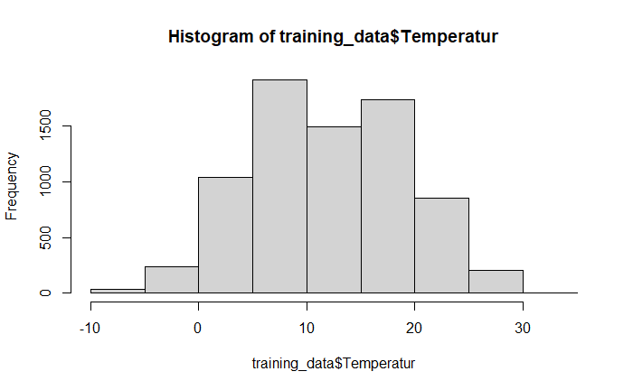

```r
# show distribution of data
hist(training_data$Temperatur)
```

```r
# approach one: create 8 bins of equal width for the temperature
training_data1 <- training_data %>%
  mutate(Temperatur_bins = cut(Temperatur, 8, include.lowest = TRUE))

# check new added temperature_bins column and its unique values
head(training_data1)
```

| id | Datum | Warengruppe | Umsatz | KielerWoche | Bewoelkung | Temperatur | Windgeschwindigkeit | Wettercode | Schulferien | Feiertag | Wochenende | Season | Temperatur_bins |
| --- | --- | --- | --- | --- | --- | --- | --- | --- | --- | --- | --- | --- | --- |
| 1307011 | 2013-07-01 | 1 | 148.82835 | 0 | 6 | 17.8375 | 15 | 20 | 1 | 0 | 0 | Summer | (16.5,21.5] |
| 1307012 | 2013-07-01 | 2 | 535.85628 | 0 | 6 | 17.8375 | 15 | 20 | 1 | 0 | 0 | Summer | (16.5,21.5] |
| 1307013 | 2013-07-01 | 3 | 201.19843 | 0 | 6 | 17.8375 | 15 | 20 | 1 | 0 | 0 | Summer | (16.5,21.5] |
| 1307014 | 2013-07-01 | 4 | 65.89017 | 0 | 6 | 17.8375 | 15 | 20 | 1 | 0 | 0 | Summer | (16.5,21.5] |
| 1307015 | 2013-07-01 | 5 | 317.47587 | 0 | 6 | 17.8375 | 15 | 20 | 1 | 0 | 0 | Summer | (16.5,21.5] |
| 1307021 | 2013-07-02 | 1 | 159.79376 | 0 | 3 | 17.3125 | 10 | NA | 1 | 0 | 0 | Summer | (16.5,21.5] |

```r
training_data1 %>% distinct(Temperatur_bins) %>% arrange(Temperatur_bins)
```

| Temperatur_bins |
| --- |
| [-8.51,-3.49] |
| (-3.49,1.5] |
| (1.5,6.49] |
| (6.49,11.5] |
| (11.5,16.5] |
| (16.5,21.5] |
| (21.5,26.4] |
| (26.4,31.5] |
| NA |

```r
# approach two: create 7 manual bins
training_data2 <- training_data %>%
  mutate(Temperatur_bins = cut(Temperatur,
                               breaks = c(-10, 0, 5, 10, 15, 20, 25, 35),
                               include.lowest = TRUE))

# check new added temperature_bins column and its unique values
head(training_data2)
```

| id | Datum | Warengruppe | Umsatz | KielerWoche | Bewoelkung | Temperatur | Windgeschwindigkeit | Wettercode | Schulferien | Feiertag | Wochenende | Season | Temperatur_bins |
| --- | --- | --- | --- | --- | --- | --- | --- | --- | --- | --- | --- | --- | --- |
| 1307011 | 2013-07-01 | 1 | 148.82835 | 0 | 6 | 17.8375 | 15 | 20 | 1 | 0 | 0 | Summer | (15,20] |
| 1307012 | 2013-07-01 | 2 | 535.85628 | 0 | 6 | 17.8375 | 15 | 20 | 1 | 0 | 0 | Summer | (15,20] |
| 1307013 | 2013-07-01 | 3 | 201.19843 | 0 | 6 | 17.8375 | 15 | 20 | 1 | 0 | 0 | Summer | (15,20] |
| 1307014 | 2013-07-01 | 4 | 65.89017 | 0 | 6 | 17.8375 | 15 | 20 | 1 | 0 | 0 | Summer | (15,20] |
| 1307015 | 2013-07-01 | 5 | 317.47587 | 0 | 6 | 17.8375 | 15 | 20 | 1 | 0 | 0 | Summer | (15,20] |
| 1307021 | 2013-07-02 | 1 | 159.79376 | 0 | 3 | 17.3125 | 10 | NA | 1 | 0 | 0 | Summer | (15,20] |

```r
training_data2 %>% distinct(Temperatur_bins) %>% arrange(Temperatur_bins)
```

| Temperatur_bins |
| --- |
| [-10,0] |
| (0,5] |
| (5,10] |
| (10,15] |
| (15,20] |
| (20,25] |
| (25,35] |
| NA |

```r
NA
```

The last step will be setting up the linear model equation with the training data set and searching for the model with the best adjusted R-squared value.

```r
# model 1
mod1 <- lm(Umsatz ~ as.factor(Warengruppe) + Temperatur_bins, training_data1)
summary(mod1)
```

```
Call:
lm(formula = Umsatz ~ as.factor(Warengruppe) + Temperatur_bins,
    data = training_data1)

Residuals:
    Min      1Q  Median      3Q     Max
-204.74  -45.28   -8.09   30.21 1620.44

Coefficients:
                           Estimate Std. Error t value Pr(>|t|)
(Intercept)                  80.777     10.836   7.454 1.00e-13 ***
as.factor(Warengruppe)2     289.164      3.056  94.632  < 2e-16 ***
as.factor(Warengruppe)3      42.756      3.056  13.992  < 2e-16 ***
as.factor(Warengruppe)4     -32.889      3.084 -10.663  < 2e-16 ***
as.factor(Warengruppe)5     159.523      3.056  52.206  < 2e-16 ***
as.factor(Warengruppe)6     -30.640      5.870  -5.220 1.84e-07 ***
Temperatur_bins(-3.49,1.5]    3.708     11.510   0.322   0.7473
Temperatur_bins(1.5,6.49]     9.803     10.895   0.900   0.3683
Temperatur_bins(6.49,11.5]   18.725     10.833   1.729   0.0839 .
Temperatur_bins(11.5,16.5]   44.701     10.889   4.105 4.09e-05 ***
Temperatur_bins(16.5,21.5]   74.146     10.850   6.834 8.92e-12 ***
Temperatur_bins(21.5,26.4]   89.276     11.176   7.988 1.57e-15 ***
Temperatur_bins(26.4,31.5]   80.873     14.530   5.566 2.70e-08 ***
---
Signif. codes:  0 ‘***’ 0.001 ‘**’ 0.01 ‘*’ 0.05 ‘.’ 0.1 ‘ ’ 1

Residual standard error: 82.59 on 7474 degrees of freedom
  (36 Beobachtungen als fehlend gelöscht)
Multiple R-squared:  0.6881,    Adjusted R-squared:  0.6876
F-statistic:  1374 on 12 and 7474 DF,  p-value: < 2.2e-16
```

Model 1: Adjusted R-squared: 0.6876

Almost all variables seem to be relevant and will be kept for further the models.

```r
# model 2
mod2 <- lm(Umsatz ~ as.factor(Warengruppe) + Temperatur_bins + Bewoelkung, training_data1)
summary(mod2)
```

```
Call:
lm(formula = Umsatz ~ as.factor(Warengruppe) + Temperatur_bins +
    Bewoelkung, data = training_data1)

Residuals:
    Min      1Q  Median      3Q     Max
-204.16  -45.43   -7.77   30.30 1620.76

Coefficients:
                           Estimate Std. Error t value Pr(>|t|)
(Intercept)                 82.8185    10.9881   7.537 5.37e-14 ***
as.factor(Warengruppe)2    289.1639     3.0556  94.633  < 2e-16 ***
as.factor(Warengruppe)3     42.7563     3.0556  13.993  < 2e-16 ***
as.factor(Warengruppe)4    -32.8922     3.0843 -10.664  < 2e-16 ***
as.factor(Warengruppe)5    159.5235     3.0556  52.207  < 2e-16 ***
as.factor(Warengruppe)6    -30.5542     5.8703  -5.205 1.99e-07 ***
Temperatur_bins(-3.49,1.5]   4.3610    11.5241   0.378    0.705
Temperatur_bins(1.5,6.49]   10.2997    10.9042   0.945    0.345
Temperatur_bins(6.49,11.5]  19.0368    10.8359   1.757    0.079 .
Temperatur_bins(11.5,16.5]  44.8272    10.8898   4.116 3.89e-05 ***
Temperatur_bins(16.5,21.5]  73.9082    10.8518   6.811 1.05e-11 ***
Temperatur_bins(21.5,26.4]  88.2691    11.2117   7.873 3.95e-15 ***
Temperatur_bins(26.4,31.5]  79.2767    14.5993   5.430 5.81e-08 ***
Bewoelkung                  -0.4454     0.3975  -1.121    0.263
---
Signif. codes:  0 ‘***’ 0.001 ‘**’ 0.01 ‘*’ 0.05 ‘.’ 0.1 ‘ ’ 1

Residual standard error: 82.59 on 7473 degrees of freedom
  (36 Beobachtungen als fehlend gelöscht)
Multiple R-squared:  0.6882,    Adjusted R-squared:  0.6877
F-statistic:  1269 on 13 and 7473 DF,  p-value: < 2.2e-16
```

Model 2: Adjusted R-squared: 0.6877

The R-squared is just slightly better than model 1, but the p-value of Bewoelkung indicates that it is not as relevant to the model as most of the other variables. It will be not be used in the next model.

```r
# model 3
mod3 <- lm(Umsatz ~ as.factor(Warengruppe) + Temperatur_bins + Windgeschwindigkeit, training_data1)
summary(mod3)
```

```
Call:
lm(formula = Umsatz ~ as.factor(Warengruppe) + Temperatur_bins +
    Windgeschwindigkeit, data = training_data1)

Residuals:
    Min      1Q  Median      3Q     Max
-206.99  -45.44   -7.90   30.24 1621.01

Coefficients:
                           Estimate Std. Error t value Pr(>|t|)
(Intercept)                 75.5080    11.1049   6.799 1.13e-11 ***
as.factor(Warengruppe)2    289.1639     3.0549  94.655  < 2e-16 ***
as.factor(Warengruppe)3     42.7563     3.0549  13.996  < 2e-16 ***
as.factor(Warengruppe)4    -32.8759     3.0836 -10.661  < 2e-16 ***
as.factor(Warengruppe)5    159.5235     3.0549  52.218  < 2e-16 ***
as.factor(Warengruppe)6    -30.3228     5.8703  -5.165 2.46e-07 ***
Temperatur_bins(-3.49,1.5]   4.4543    11.5119   0.387   0.6988
Temperatur_bins(1.5,6.49]    9.7329    10.8927   0.894   0.3716
Temperatur_bins(6.49,11.5]  17.8611    10.8373   1.648   0.0994 .
Temperatur_bins(11.5,16.5]  44.2462    10.8888   4.063 4.88e-05 ***
Temperatur_bins(16.5,21.5]  73.9053    10.8478   6.813 1.03e-11 ***
Temperatur_bins(21.5,26.4]  89.3980    11.1733   8.001 1.42e-15 ***
Temperatur_bins(26.4,31.5]  81.4444    14.5288   5.606 2.15e-08 ***
Windgeschwindigkeit          0.5055     0.2342   2.159   0.0309 *
---
Signif. codes:  0 ‘***’ 0.001 ‘**’ 0.01 ‘*’ 0.05 ‘.’ 0.1 ‘ ’ 1

Residual standard error: 82.57 on 7473 degrees of freedom
  (36 Beobachtungen als fehlend gelöscht)
Multiple R-squared:  0.6883,    Adjusted R-squared:  0.6878
F-statistic:  1270 on 13 and 7473 DF,  p-value: < 2.2e-16
```

Model 3: Adjusted R-squared: 0.6878

The R-squared is again just slightly better than model 1, the p-value of Windgeschwindigkeit indicates that it is relevant to the model, but less relevant than most other variables.

```r
# model 4
mod4 <- lm(Umsatz ~ as.factor(Warengruppe) + Temperatur_bins + Windgeschwindigkeit + Wochenende, training_data1)
summary(mod4)
```

```
Call:
lm(formula = Umsatz ~ as.factor(Warengruppe) + Temperatur_bins +
    Windgeschwindigkeit + Wochenende, data = training_data1)

Residuals:
    Min      1Q  Median      3Q     Max
-191.38  -43.30   -5.22   30.92 1635.10

Coefficients:
                           Estimate Std. Error t value Pr(>|t|)
(Intercept)                 63.8595    10.6569   5.992 2.16e-09 ***
as.factor(Warengruppe)2    289.1639     2.9290  98.724  < 2e-16 ***
as.factor(Warengruppe)3     42.7563     2.9290  14.598  < 2e-16 ***
as.factor(Warengruppe)4    -33.0732     2.9565 -11.187  < 2e-16 ***
as.factor(Warengruppe)5    159.5235     2.9290  54.463  < 2e-16 ***
as.factor(Warengruppe)6    -30.3891     5.6283  -5.399 6.90e-08 ***
Temperatur_bins(-3.49,1.5]   1.9788    11.0379   0.179   0.8577
Temperatur_bins(1.5,6.49]    7.6650    10.4440   0.734   0.4630
Temperatur_bins(6.49,11.5]  16.8364    10.3906   1.620   0.1052
Temperatur_bins(11.5,16.5]  43.4069    10.4400   4.158 3.25e-05 ***
Temperatur_bins(16.5,21.5]  70.9446    10.4013   6.821 9.77e-12 ***
Temperatur_bins(21.5,26.4]  86.7123    10.7132   8.094 6.69e-16 ***
Temperatur_bins(26.4,31.5]  86.8746    13.9315   6.236 4.74e-10 ***
Windgeschwindigkeit          0.3792     0.2246   1.689   0.0913 .
Wochenende                  52.0159     2.0288  25.639  < 2e-16 ***
---
Signif. codes:  0 ‘***’ 0.001 ‘**’ 0.01 ‘*’ 0.05 ‘.’ 0.1 ‘ ’ 1

Residual standard error: 79.16 on 7472 degrees of freedom
  (36 Beobachtungen als fehlend gelöscht)
Multiple R-squared:  0.7135,    Adjusted R-squared:  0.713
F-statistic:  1329 on 14 and 7472 DF,  p-value: < 2.2e-16
```

Model 4: Adjusted R-squared: 0.713

This is so far the best R-squared. The p-value of the variable Windgeschwindigkeit indicates, that it is less relevant and will not be used in the next model.

```r
# model 5
mod5 <- lm(Umsatz ~ as.factor(Warengruppe) + Temperatur_bins + Wochenende, training_data1)
summary(mod5)
```

```
Call:
lm(formula = Umsatz ~ as.factor(Warengruppe) + Temperatur_bins +
    Wochenende, data = training_data1)

Residuals:
    Min      1Q  Median      3Q     Max
-189.67  -43.52   -5.12   30.86 1634.91

Coefficients:
                           Estimate Std. Error t value Pr(>|t|)
(Intercept)                  67.793     10.401   6.518 7.58e-11 ***
as.factor(Warengruppe)2     289.164      2.929  98.712  < 2e-16 ***
as.factor(Warengruppe)3      42.756      2.929  14.596  < 2e-16 ***
as.factor(Warengruppe)4     -33.083      2.957 -11.189  < 2e-16 ***
as.factor(Warengruppe)5     159.523      2.929  54.457  < 2e-16 ***
as.factor(Warengruppe)6     -30.627      5.627  -5.443 5.42e-08 ***
Temperatur_bins(-3.49,1.5]    1.416     11.034   0.128   0.8979
Temperatur_bins(1.5,6.49]     7.714     10.445   0.739   0.4602
Temperatur_bins(6.49,11.5]   17.482     10.385   1.683   0.0923 .
Temperatur_bins(11.5,16.5]   43.747     10.439   4.191 2.81e-05 ***
Temperatur_bins(16.5,21.5]   71.121     10.402   6.837 8.72e-12 ***
Temperatur_bins(21.5,26.4]   86.617     10.714   8.084 7.24e-16 ***
Temperatur_bins(26.4,31.5]   86.454     13.931   6.206 5.73e-10 ***
Wochenende                   52.091      2.029  25.679  < 2e-16 ***
---
Signif. codes:  0 ‘***’ 0.001 ‘**’ 0.01 ‘*’ 0.05 ‘.’ 0.1 ‘ ’ 1

Residual standard error: 79.17 on 7473 degrees of freedom
  (36 Beobachtungen als fehlend gelöscht)
Multiple R-squared:  0.7134,    Adjusted R-squared:  0.7129
F-statistic:  1431 on 13 and 7473 DF,  p-value: < 2.2e-16
```

Model 5: Adjusted R-squared: 0.7129

This models R-squared differs from model 4 by only 0.0001, but works without the variable Windgeschwindigkeit. Therefore, it won’t be considered in the following model.

```r
# model 6
mod6 <- lm(Umsatz ~ as.factor(Warengruppe) + Temperatur_bins + Wochenende + KielerWoche + Schulferien,            training_data1)
summary(mod6)
```

```
Call:
lm(formula = Umsatz ~ as.factor(Warengruppe) + Temperatur_bins +
    Wochenende + KielerWoche + Schulferien, data = training_data1)

Residuals:
    Min      1Q  Median      3Q     Max
-200.92  -41.81   -5.67   34.08 1595.06

Coefficients:
                           Estimate Std. Error t value Pr(>|t|)
(Intercept)                  50.806     10.094   5.033 4.93e-07 ***
as.factor(Warengruppe)2     289.164      2.835 101.999  < 2e-16 ***
as.factor(Warengruppe)3      42.756      2.835  15.082  < 2e-16 ***
as.factor(Warengruppe)4     -32.597      2.862 -11.391  < 2e-16 ***
as.factor(Warengruppe)5     159.523      2.835  56.270  < 2e-16 ***
as.factor(Warengruppe)6     -29.279      5.446  -5.376 7.85e-08 ***
Temperatur_bins(-3.49,1.5]   13.664     10.692   1.278   0.2013
Temperatur_bins(1.5,6.49]    18.766     10.121   1.854   0.0637 .
Temperatur_bins(6.49,11.5]   24.306     10.055   2.417   0.0157 *
Temperatur_bins(11.5,16.5]   48.455     10.106   4.794 1.66e-06 ***
Temperatur_bins(16.5,21.5]   72.816     10.076   7.227 5.43e-13 ***
Temperatur_bins(21.5,26.4]   79.491     10.375   7.662 2.07e-14 ***
Temperatur_bins(26.4,31.5]   73.035     13.501   5.410 6.51e-08 ***
Wochenende                   53.290      1.967  27.095  < 2e-16 ***
KielerWoche                  23.760      5.961   3.986 6.78e-05 ***
Schulferien                  49.770      2.213  22.488  < 2e-16 ***
---
Signif. codes:  0 ‘***’ 0.001 ‘**’ 0.01 ‘*’ 0.05 ‘.’ 0.1 ‘ ’ 1

Residual standard error: 76.62 on 7471 degrees of freedom
  (36 Beobachtungen als fehlend gelöscht)
Multiple R-squared:  0.7317,    Adjusted R-squared:  0.7311
F-statistic:  1358 on 15 and 7471 DF,  p-value: < 2.2e-16
```

Model 6: Adjusted R-squared: 0.7311

This model with the additional features KielerWoche and Schulferien is even better than the one before.

```r
# model 7 with training_data2
mod7 <- lm(Umsatz ~ as.factor(Warengruppe) + Temperatur_bins + Wochenende + KielerWoche + Schulferien,            training_data2)
summary(mod7)
```

```
Call:
lm(formula = Umsatz ~ as.factor(Warengruppe) + Temperatur_bins +
    Wochenende + KielerWoche + Schulferien, data = training_data2)

Residuals:
    Min      1Q  Median      3Q     Max
-194.89  -42.16   -4.92   33.15 1598.16

Coefficients:
                        Estimate Std. Error t value Pr(>|t|)
(Intercept)               61.829      5.098  12.129  < 2e-16 ***
as.factor(Warengruppe)2  289.164      2.831 102.124  < 2e-16 ***
as.factor(Warengruppe)3   42.756      2.831  15.100  < 2e-16 ***
as.factor(Warengruppe)4  -32.549      2.858 -11.388  < 2e-16 ***
as.factor(Warengruppe)5  159.523      2.831  56.339  < 2e-16 ***
as.factor(Warengruppe)6  -29.207      5.435  -5.374 7.95e-08 ***
Temperatur_bins(0,5]       6.182      5.294   1.168   0.2430
Temperatur_bins(5,10]     11.686      5.036   2.320   0.0204 *
Temperatur_bins(10,15]    27.182      5.121   5.308 1.14e-07 ***
Temperatur_bins(15,20]    57.276      5.085  11.263  < 2e-16 ***
Temperatur_bins(20,25]    71.680      5.440  13.176  < 2e-16 ***
Temperatur_bins(25,35]    66.720      7.137   9.348  < 2e-16 ***
Wochenende                52.275      1.968  26.564  < 2e-16 ***
KielerWoche               23.497      5.947   3.951 7.86e-05 ***
Schulferien               48.263      2.222  21.719  < 2e-16 ***
---
Signif. codes:  0 ‘***’ 0.001 ‘**’ 0.01 ‘*’ 0.05 ‘.’ 0.1 ‘ ’ 1

Residual standard error: 76.53 on 7472 degrees of freedom
  (36 Beobachtungen als fehlend gelöscht)
Multiple R-squared:  0.7323,    Adjusted R-squared:  0.7318
F-statistic:  1460 on 14 and 7472 DF,  p-value: < 2.2e-16
```

Model 7: Adjusted R-squared: 0.7318

Again, this model with the 7 manually chosen bins is slightly better than the one with the 8 automatically created bins. How about even less bins?

```r
# approach three: create 4 manual bins
training_data3 <- training_data %>%
  mutate(Temperatur_bins = cut(Temperatur,
                               breaks = c(-10, 0, 10, 20, 35),
                               include.lowest = TRUE))

# check new added temperature_bins column and its unique values
head(training_data3)
```

| id | Datum | Warengruppe | Umsatz | KielerWoche | Bewoelkung | Temperatur | Windgeschwindigkeit | Wettercode | Schulferien | Feiertag | Wochenende | Season | Temperatur_bins |
| --- | --- | --- | --- | --- | --- | --- | --- | --- | --- | --- | --- | --- | --- |
| 1307011 | 2013-07-01 | 1 | 148.82835 | 0 | 6 | 17.8375 | 15 | 20 | 1 | 0 | 0 | Summer | (10,20] |
| 1307012 | 2013-07-01 | 2 | 535.85628 | 0 | 6 | 17.8375 | 15 | 20 | 1 | 0 | 0 | Summer | (10,20] |
| 1307013 | 2013-07-01 | 3 | 201.19843 | 0 | 6 | 17.8375 | 15 | 20 | 1 | 0 | 0 | Summer | (10,20] |
| 1307014 | 2013-07-01 | 4 | 65.89017 | 0 | 6 | 17.8375 | 15 | 20 | 1 | 0 | 0 | Summer | (10,20] |
| 1307015 | 2013-07-01 | 5 | 317.47587 | 0 | 6 | 17.8375 | 15 | 20 | 1 | 0 | 0 | Summer | (10,20] |
| 1307021 | 2013-07-02 | 1 | 159.79376 | 0 | 3 | 17.3125 | 10 | NA | 1 | 0 | 0 | Summer | (10,20] |

```r
training_data3 %>% distinct(Temperatur_bins) %>% arrange(Temperatur_bins)
```

| Temperatur_bins |
| --- |
| [-10,0] |
| (0,10] |
| (10,20] |
| (20,35] |
| NA |

```r
# model 8 with training_data3
mod8 <- lm(Umsatz ~ as.factor(Warengruppe) + Temperatur_bins + Wochenende + KielerWoche + Schulferien,            training_data3)
summary(mod8)
```

```
Call:
lm(formula = Umsatz ~ as.factor(Warengruppe) + Temperatur_bins +
    Wochenende + KielerWoche + Schulferien, data = training_data3)

Residuals:
    Min      1Q  Median      3Q     Max
-194.57  -42.76   -5.07   33.72 1599.89

Coefficients:
                        Estimate Std. Error t value Pr(>|t|)
(Intercept)               61.363      5.139  11.941  < 2e-16 ***
as.factor(Warengruppe)2  289.164      2.855 101.300  < 2e-16 ***
as.factor(Warengruppe)3   42.756      2.855  14.978  < 2e-16 ***
as.factor(Warengruppe)4  -32.540      2.881 -11.293  < 2e-16 ***
as.factor(Warengruppe)5  159.523      2.855  55.884  < 2e-16 ***
as.factor(Warengruppe)6  -32.042      5.473  -5.854 5.00e-09 ***
Temperatur_bins(0,10]      9.867      4.969   1.986   0.0471 *
Temperatur_bins(10,20]    42.951      4.956   8.666  < 2e-16 ***
Temperatur_bins(20,35]    70.121      5.359  13.084  < 2e-16 ***
Wochenende                53.876      1.979  27.230  < 2e-16 ***
KielerWoche               31.246      5.954   5.248 1.58e-07 ***
Schulferien               48.820      2.234  21.856  < 2e-16 ***
---
Signif. codes:  0 ‘***’ 0.001 ‘**’ 0.01 ‘*’ 0.05 ‘.’ 0.1 ‘ ’ 1

Residual standard error: 77.15 on 7475 degrees of freedom
  (36 Beobachtungen als fehlend gelöscht)
Multiple R-squared:  0.7278,    Adjusted R-squared:  0.7274
F-statistic:  1817 on 11 and 7475 DF,  p-value: < 2.2e-16
```

Model 8: Adjusted R-squared: 0.7274

The R-squared is smaller than before, so the model 7 with 7 bins is be the best option for now.

```r
# model 9 with Feiertag and Season
mod9 <- lm(Umsatz ~ as.factor(Warengruppe) + Temperatur_bins + Wochenende + KielerWoche + Schulferien + Feiertag + Season, training_data2)
summary(mod9)
```

```
Call:
lm(formula = Umsatz ~ as.factor(Warengruppe) + Temperatur_bins +
    Wochenende + KielerWoche + Schulferien + Feiertag + Season,
    data = training_data2)

Residuals:
    Min      1Q  Median      3Q     Max
-182.00  -40.94   -4.25   33.94 1603.17

Coefficients:
                        Estimate Std. Error t value Pr(>|t|)
(Intercept)               63.728      5.834  10.923  < 2e-16 ***
as.factor(Warengruppe)2  289.164      2.790 103.629  < 2e-16 ***
as.factor(Warengruppe)3   42.756      2.790  15.323  < 2e-16 ***
as.factor(Warengruppe)4  -32.591      2.817 -11.571  < 2e-16 ***
as.factor(Warengruppe)5  159.523      2.790  57.169  < 2e-16 ***
as.factor(Warengruppe)6  -28.643      5.407  -5.297 1.21e-07 ***
Temperatur_bins(0,5]       5.619      5.265   1.067   0.2859
Temperatur_bins(5,10]     11.320      5.228   2.165   0.0304 *
Temperatur_bins(10,15]    21.991      5.639   3.900 9.70e-05 ***
Temperatur_bins(15,20]    37.191      5.884   6.321 2.75e-10 ***
Temperatur_bins(20,25]    43.166      6.382   6.764 1.44e-11 ***
Temperatur_bins(25,35]    37.126      7.884   4.709 2.53e-06 ***
Wochenende                53.940      1.942  27.769  < 2e-16 ***
KielerWoche                6.438      6.037   1.066   0.2862
Schulferien               43.239      2.232  19.371  < 2e-16 ***
Feiertag                  74.918      8.317   9.008  < 2e-16 ***
SeasonSpring              -2.864      2.534  -1.130   0.2584
SeasonSummer              35.639      3.145  11.331  < 2e-16 ***
SeasonWinter              -1.514      3.048  -0.497   0.6194
---
Signif. codes:  0 ‘***’ 0.001 ‘**’ 0.01 ‘*’ 0.05 ‘.’ 0.1 ‘ ’ 1

Residual standard error: 75.42 on 7468 degrees of freedom
  (36 Beobachtungen als fehlend gelöscht)
Multiple R-squared:  0.7402,    Adjusted R-squared:  0.7395
F-statistic:  1182 on 18 and 7468 DF,  p-value: < 2.2e-16
```

Model 9: Adjusted R-squared: 0.7395

This model is again slightly better than model 7.

```r
# model 10 with interaction effects
mod10 <- lm(Umsatz ~ as.factor(Warengruppe) + Temperatur_bins + Wochenende + KielerWoche + Schulferien + Feiertag + Season + (Season * as.factor(Warengruppe)) + (Wochenende * as.factor(Warengruppe)) + (Schulferien * as.factor(Warengruppe)) + (Temperatur_bins * as.factor(Warengruppe)) + (Temperatur_bins * Schulferien), training_data2)
summary(mod10)
```

```
Call:
lm(formula = Umsatz ~ as.factor(Warengruppe) + Temperatur_bins +
    Wochenende + KielerWoche + Schulferien + Feiertag + Season +
    (Season * as.factor(Warengruppe)) + (Wochenende * as.factor(Warengruppe)) +
    (Schulferien * as.factor(Warengruppe)) + (Temperatur_bins *
    as.factor(Warengruppe)) + (Temperatur_bins * Schulferien),
    data = training_data2)

Residuals:
    Min      1Q  Median      3Q     Max
-255.95  -28.16   -3.63   22.89 1582.57

Coefficients: (4 not defined because of singularities)
                                               Estimate Std. Error t value Pr(>|t|)
(Intercept)                                    121.3707    10.5821  11.469  < 2e-16 ***
as.factor(Warengruppe)2                        152.1972    14.7656  10.308  < 2e-16 ***
as.factor(Warengruppe)3                         -5.0176    14.7656  -0.340 0.734006
as.factor(Warengruppe)4                        -60.5625    14.8173  -4.087 4.41e-05 ***
as.factor(Warengruppe)5                        119.6226    14.7656   8.101 6.30e-16 ***
as.factor(Warengruppe)6                        -49.5129    25.8008  -1.919 0.055017 .
Temperatur_bins(0,5]                           -13.1501     9.9970  -1.315 0.188414
Temperatur_bins(5,10]                           -5.1988     9.9548  -0.522 0.601522
Temperatur_bins(10,15]                           1.7614    10.7412   0.164 0.869748
Temperatur_bins(15,20]                           6.4078    11.1542   0.574 0.565669
Temperatur_bins(20,25]                          -7.3242    12.1136  -0.605 0.545450
Temperatur_bins(25,35]                         -11.6852    15.1632  -0.771 0.440950
Wochenende                                     -15.4797     3.6046  -4.294 1.77e-05 ***
KielerWoche                                      7.5394     5.0158   1.503 0.132853
Schulferien                                    -12.9556    10.6285  -1.219 0.222901
Feiertag                                        74.1996     6.8378  10.851  < 2e-16 ***
SeasonSpring                                    -0.2753     4.6753  -0.059 0.953042
SeasonSummer                                     7.7913     5.6737   1.373 0.169724
SeasonWinter                                    -5.4800     5.8391  -0.939 0.348015
as.factor(Warengruppe)2:SeasonSpring            -3.5621     6.6011  -0.540 0.589467
as.factor(Warengruppe)3:SeasonSpring           -11.7389     6.6011  -1.778 0.075390 .
as.factor(Warengruppe)4:SeasonSpring            -1.9828     6.6445  -0.298 0.765392
as.factor(Warengruppe)5:SeasonSpring            -4.0792     6.6011  -0.618 0.536621
as.factor(Warengruppe)6:SeasonSpring                 NA         NA      NA       NA
as.factor(Warengruppe)2:SeasonSummer            82.1965     7.9392  10.353  < 2e-16 ***
as.factor(Warengruppe)3:SeasonSummer            41.7212     7.9392   5.255 1.52e-07 ***
```

[output cut: 46 more lines]

```
as.factor(Warengruppe)5:Temperatur_bins(25,35]  -4.1303    20.6168  -0.200 0.841222
as.factor(Warengruppe)6:Temperatur_bins(25,35]       NA         NA      NA       NA
Temperatur_bins(0,5]:Schulferien                96.2546    12.6386   7.616 2.94e-14 ***
Temperatur_bins(5,10]:Schulferien               41.0073    10.6850   3.838 0.000125 ***
Temperatur_bins(10,15]:Schulferien              12.4130    10.6780   1.162 0.245076
Temperatur_bins(15,20]:Schulferien              33.7850    10.6299   3.178 0.001488 **
Temperatur_bins(20,25]:Schulferien              41.4047    10.8970   3.800 0.000146 ***
Temperatur_bins(25,35]:Schulferien              52.9358    13.2192   4.004 6.28e-05 ***
---
Signif. codes:  0 ‘***’ 0.001 ‘**’ 0.01 ‘*’ 0.05 ‘.’ 0.1 ‘ ’ 1

Residual standard error: 61.87 on 7411 degrees of freedom
  (36 Beobachtungen als fehlend gelöscht)
Multiple R-squared:  0.8265,    Adjusted R-squared:  0.8247
F-statistic: 470.6 on 75 and 7411 DF,  p-value: < 2.2e-16
```

Model 10: Adjusted R-squared: 0.8247

This model contains various interaction effects and is by far the best model.

Preparation for the next step of putting model 10 to use:

```r
# create 7 manual bins for validation data and test data as well
validation_data2 <- validation_data %>%
  mutate(Temperatur_bins = cut(Temperatur,
                               breaks = c(-10, 0, 5, 10, 15, 20, 25, 35),
                               include.lowest = TRUE))

test_data2 <- test_data2 %>%
  mutate(Temperatur_bins = cut(Temperatur,
                               breaks = c(-10, 0, 5, 10, 15, 20, 25, 35),
                               include.lowest = TRUE))

head(validation_data2)
```

| id | Datum | Warengruppe | Umsatz | KielerWoche | Bewoelkung | Temperatur | Windgeschwindigkeit | Wettercode | Schulferien | Feiertag | Wochenende | Season | Temperatur_bins |
| --- | --- | --- | --- | --- | --- | --- | --- | --- | --- | --- | --- | --- | --- |
| 1708011 | 2017-08-01 | 1 | 166.13549 | 0 | 6 | 21.375 | 7 | 21 | 1 | 0 | 0 | Summer | (20,25] |
| 1708012 | 2017-08-01 | 2 | 557.47090 | 0 | 6 | 21.375 | 7 | 21 | 1 | 0 | 0 | Summer | (20,25] |
| 1708013 | 2017-08-01 | 3 | 294.87270 | 0 | 6 | 21.375 | 7 | 21 | 1 | 0 | 0 | Summer | (20,25] |
| 1708014 | 2017-08-01 | 4 | 88.20801 | 0 | 6 | 21.375 | 7 | 21 | 1 | 0 | 0 | Summer | (20,25] |
| 1708015 | 2017-08-01 | 5 | 325.86423 | 0 | 6 | 21.375 | 7 | 21 | 1 | 0 | 0 | Summer | (20,25] |
| 1708021 | 2017-08-02 | 1 | 155.02210 | 0 | 5 | 21.375 | 8 | 61 | 1 | 0 | 0 | Summer | (20,25] |

```r
# save the training and validation data as csv-files for the next step
write.csv(training_data2, file = "../3_Model/training_data2.csv", row.names = FALSE)
write.csv(validation_data2, file = "../3_Model/validation_data2.csv", row.names = FALSE)
write.csv(test_data2, file = "../3_Model/test_data2.csv", row.names = FALSE)
```